# Trabajo Reconocimiento de dígitos.

Nombre: Jairo

Apellidos: Peña Iglesias

```r
## Cargamos los paquetes
library("dplyr")
```

```r
library ("ggplot2")
```

## Introducción

En este trabajo, implementaremos la clasificación usando regresión logística regularizada al problema de reconocimientos de dígitos escritos a mano a partir de imagénes de 20x20 píxeles en escala de gris…

## Cargamos los datos

El fichero que contiene los datos es digitos.csv que se puede descargar del Aula Virtual y guardar en la carpeta data del directorio asociado a nuestro nuevo proyecto.

Cargar los datos en un dataframe llamado **digitos**, tendréis que usar la opción colClasses=“numeric”, para asegurar que R cargue los datos como números..

```r
## Completar aqui
digitos <- read.table(file = "data/digitos.csv", header=FALSE, sep=",", dec=".", stringsAsFactors = FALSE, colClasses="numeric")
```

Especificamos los nombres de las columnas del data.frame **digitos**: para ello, usaremos la instrucción names, valiéndonos de **paste**:

```r
## nada que completar
names(digitos) <- c("y", paste("x", 1:400, sep=""))
```

- La primera columna y contiene el dígito que está dibujado: cuando aparece un 10, corresponde al dígito “0”.
- Las demás columnas x1 a x400 contienen la intensidad de gris de los 400 pixeles de la imagen (20x20).

Encontrad, con la instrucción *table** la frecuencia de cada dígito en el conjunto..

```r
## completar aquí
table(digitos$y)
```

```
##
##   1   2   3   4   5   6   7   8   9  10
## 500 500 500 500 500 500 500 500 500 500
```

Empecemos por visualizar las imagenes que están descritas por este conjunto. Para ello, usaremos la instrucción **image**, después de transformar las columnas que contienen la intensidad de gris de cada pixel (columna x1 a x400) en una matriz 20x20.

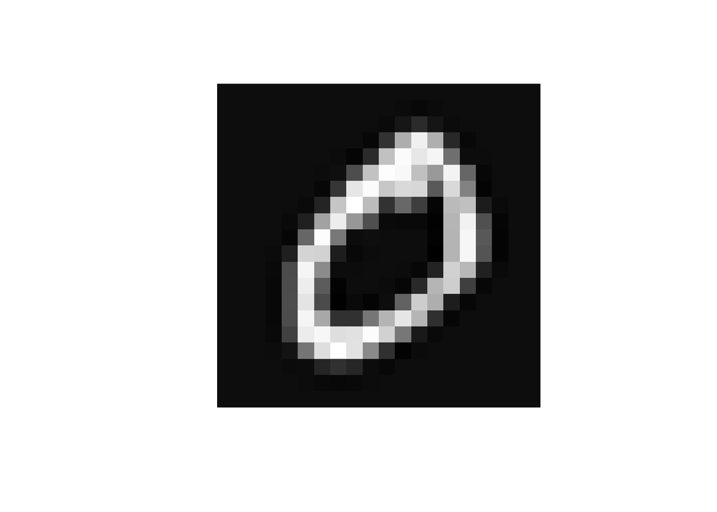

```r
## nada que completar
rotate <- function(x) t(apply(x, 2, rev))
m=matrix(as.numeric(digitos[1, 2:401]), nrow=20, ncol=20, byrow=FALSE)
image(z = rotate(m), axes = FALSE, col = grey(seq(0, 1, length = 256)), asp = 1)
```

En el bloque anterior, hemos representado la primera imagen, es claramente un 0, por lo que el valor de la columna y es 10…

En el siguiente código, representamos 16 de estas imágenes extraidas al azar de nuestro conjunto.

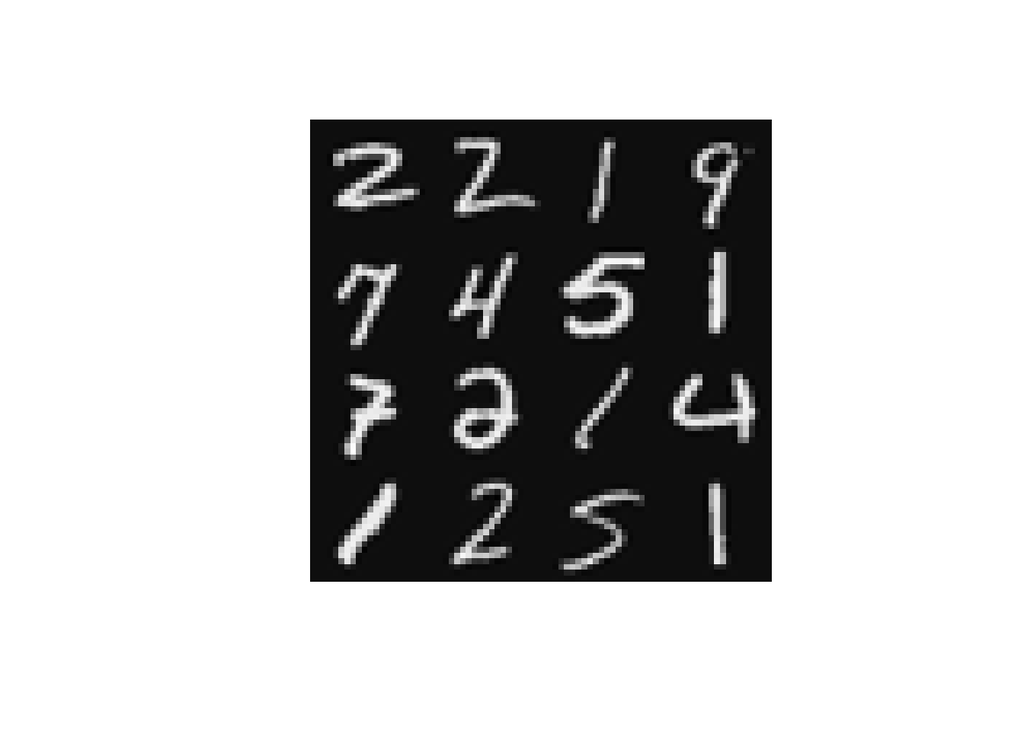

```r
## nada que completar
iselect <- sample(1:dim(digitos)[1], size = 16, replace = FALSE)
ncolumnas <- sqrt(length(iselect))
nfilas <- ncolumnas
m={}
for (i in 1:nfilas){
  mfila={}
  for (j in 1:ncolumnas){
    m.tmp <-
      matrix(as.vector(t(digitos[iselect[1 + (i - 1) * ncolumnas + j - 1],
                                 2:401])), ncol = 20 , nrow = 20)
    mfila <- cbind(mfila, m.tmp)
    }
 m <- rbind(m, mfila)
}
image(z = rotate(m), axes = FALSE,
      col = grey(seq(0, 1, length = 256)), asp = 1)
```

## Cargamos el fichero de funciones

Para evitar tener que volver a introducir funciones que ya definimos en el trabajo anterior, cargamos con la instrucción **source**, el fichero funciones-auxiliares-logistica-regularizada.R que habréis descargado del Aula Virtual y tiene que estar situado en vuestro directorio de trabajo.

```r
## nada que completar
source('funciones-auxiliares-logistica-regularizada.R')
```

Como resultado de este source, tenemos definidas las funciones - g(z): la función sigmoidal - Jreg(theta,lambda,x.mat,y): la función de coste regularizada para la regresión logística - gradJreg(theta,lambda,x.mat,y): el gradiente de la función de coste regularizada.

## Los pasos que vamos a seguir

Vamos a separar los datos que disponemos en varios subconjuntos; un conjunto de entrenamiento que nos permita entrenar nuestra regresión logística, un conjunto de validación que nos permita elegir el valor de $\lambda$ (en la función de coste regularizada) que mejores resultados dé, y finalmente un conjunto de test que nos permita comprobar la bondad del algoritmo

En resumen, éstos son los pasos que seguiremos:

1. Ajustaremos una regresión logística con función de coste regularizada sobre el conjunto de entrenamiento. Lo haremos con la modalidad de “One versus All”, y definiremos una función que, para un valor de $\lambda$ dado, devolverá como resultado un data.frame que llamaremos **theta.dat** que contenga 10 filas, (una para cada categoría en la que podemos clasificar) y 401 columnas: los valores estimados de $\theta_0,\theta_1,\ldots ,\theta_{400}$ como resultado del ajuste a nuestro conjunto de entrenamiento.
2. Usaremos el data.frame $\theta.dat$ del apartado anterior, para clasificar cada una de las observaciones del conjunto de validación. Obtendremos, para cada observación, un valor predicho para cada valor de $\lambda$. Usaremos esos valores predichos para calcular la tasa de error en la clasificación (dígitos clasificados erróneamente). Puesto que tendremos tantas columnas de valores predichos como valores de $\lambda$, tendremos un valor de la función coste sin regularizar para cada valor de $\lambda$. Nos quedaremos con el valor de $\lambda$ que lleve al menor coste (sin regularizar) para la clasificación del conjunto de validación.
3. Probaremos la clasificación sobre el conjunto test, con el valor de $\lambda$ que hemos seleccionado en el apartado anterior.

## Preparación de los tres subconjuntos: entrenamiento (60%), validación (20%), y test (20%)

### Selección de los conjuntos de entrenamiento.

```r
set.seed(seed = 1) # fijamos la semilla del algoritmo aleatorio para poder comparar
                 # nuestros resultados con los de compañeros
## completar aquí: para obtener el vector training.posiciones
rows <- c(1 : nrow(digitos))
training.posiciones <- sample(rows, nrow(digitos) * 0.6)

## completar aquí para construir el subconjunto digitos.training que corresponda
## a los digitos escogidos
digitos.training <- digitos[training.posiciones, ]
```

Si no os habéis equivocado, tenéis que haber obtenido para los 6 primeras posiciones de training.posiciones, los siguientes valores:

1328 1861 2864 4539 1008 4488

### Selección de los conjuntos de validación y test.

Debemos ahora construir el conjunto test que consistirá en los digitos que no han sido seleccionado para el conjunto training. Para ello, obtendremos primero con la instrucción **setdiff** los indices que no han sido seleccionados para el conjunto test.

```r
## nada que completar, pero sí podéis comprobar que entendéis el código:
posiciones.restantes <- setdiff(1:5000, training.posiciones)
```

Escogemos al azar la mitad de las posiciones restantes para el vector de posiciones que llamaremos **validation.posiciones** y la otra mitad para el vector de posiciones que llamaremos **test.posiciones**.

Completad el bloque de código siguiente, podréis ayudaros del bloque anterior…

```r
## completar aquí
validation.posiciones <- sample(posiciones.restantes, length(posiciones.restantes) * 0.5)
test.posiciones <- setdiff(1:2000, validation.posiciones)
```

Construimos ahora los dos conjuntos **digitos.validation** y **digitos.test**

```r
## completar aquí
digitos.validation <- digitos[validation.posiciones, ]
digitos.test <- digitos[test.posiciones, ]
```

## Regresión logística sobre el conjunto de entrenamiento

Puesto que tenemos que clasificar cada individuo en una de 10 categorías, usaremos la modalidad de “One versus All”: entrenaremos 10 regresiones logísticas:

- La primera para decidir si el digíto es un “1” o no,
- La segunda para decidir si el dígito es un “2” o no, etc…

### Entrenamiento “One versus All” para un valor concreto de $\lambda$

Empezamos, al igual que en el trabajo anterior, por crear las matrices pertinentes a partir del conjunto de entrenamiento.

```r
## nada que completar
x.training.mat <- cbind(1, as.matrix(digitos.training[, 2:401]))
y.training <- as.numeric(as.matrix((digitos.training[c("y")])))
```

Ahora, en un bucle sobre las 10 categorías en las que podemos clasificar, entrenamos nuestros 10 algoritmos de regresión logística.

Creamos una función que llamaremos **onevsall** que devuela la matriz **theta.mat**

```r
onevsall <- function(lambda,x.mat,y){
  ## Empezamos por definir la matriz theta.mat vacio
  theta.mat <- matrix(rep(NA, times = 10 * dim(x.mat)[2]),
                      nrow = 10, dim(x.mat)[2])
  ## hacemos el bucle sobre las categorías posibles
 for (i in 1:10){
   ## completar aquí para crear una variable ycod que sea igual a 1
   ## si  y corresponde a la categoría considerada i, y 0 sino
   ## (podeís usar as.numeric de un valor lógico)
  ycod <- round(y == i)
   ## completar aquí para, usando la función optim, al igual que en el trabajo anterior,
   ## el resultado de la función optim se guarda en optim.results
optim.results = optim(c(rep(0,401)), fn = Jreg, gr = gradJreg, method = "BFGS", lambda = lambda, x.mat = x.mat, y = ycod)

   ## completar aquí: guardar los parámetros ajustados en la fila número i de theta.mat
theta.mat[i, ] <- optim.results$par

 }
 return(theta.mat)
}
```

Vamos a probar nuestra nueva función al obtener la matriz theta.mat para lambda =0 por ejemplo

```r
## completar aquí
theta.mat <- onevsall(lambda=0,x.training.mat,y.training)
```

Aprovechamos **theta.mat** que acabamos de calcular para clasificar la primera imagen:

```r
## completar aquí; preparad x.mat1 la matriz que contenga las características de la primera fila de digitos
x.mat1 <- cbind(1, as.matrix(digitos.training[1, 2:401]))

## completar aquí, calcular las probabilidades que estimamos para cada una de las categorías
 g(x.mat1%*%t(theta.mat))
```

```
##              [,1]     [,2]         [,3]         [,4]         [,5]
## 1328 3.211095e-55 0.999797 1.664552e-05 6.256127e-09 2.140153e-13
##              [,6]         [,7]         [,8]        [,9]        [,10]
## 1328 9.589921e-24 2.679755e-13 0.0008168589 0.007537964 1.369692e-05
```

Y si queremos clasificar las tres primeras imágenes?

```r
## completar aquí, para clasificar las tres primera imágenes
x.mat3 <- cbind(1, as.matrix(digitos.training[1:3, 2:401]))
g(x.mat3%*%t(theta.mat))
```

```
##              [,1]         [,2]         [,3]         [,4]         [,5]
## 1328 3.211095e-55 9.997970e-01 1.664552e-05 6.256127e-09 2.140153e-13
## 1861 4.987058e-30 2.805993e-13 9.999978e-01 3.313466e-16 2.236636e-04
## 2864 7.536870e-19 1.168368e-13 2.611863e-05 2.026638e-07 9.999090e-01
##              [,6]         [,7]         [,8]         [,9]        [,10]
## 1328 9.589921e-24 2.679755e-13 0.0008168589 7.537964e-03 1.369692e-05
## 1861 4.958145e-26 1.131728e-09 0.0011942384 3.132814e-05 4.233894e-13
## 2864 2.013528e-12 2.892548e-15 0.0004847356 1.137671e-06 1.093383e-09
```

```r
## completar aquí, calcular las probabilidades que estimamos para cada una de las categorías
```

## Elección del mejor valor de $\lambda$ usando el conjunto de validación.

Ahora vamos a aprovechar la función onevsall que hemos construido en la sección anterior, para realizar el entrenamiento para varios valores de $\lambda$, usando el conjunto de entranamiento y a continuación clasificaremos las observaciones del conjunto de validación.

```r
## Nada que completar
lambdav <- c(0, 0.01*2^(0:10))
theta.array <- array(data=NA, dim = c(10, dim(x.training.mat)[2], length(lambdav)))
for (i in 1:length(lambdav))
     {
  theta.mat <- onevsall(lambda=lambdav[i],x.training.mat,y.training)
  theta.array[, , i] <- theta.mat
  print(paste("Valor lambda nº",i, " de ", length(lambdav)," hecho.",sep="" ))
}
```

```
## [1] "Valor lambda nº1 de 12 hecho."
## [1] "Valor lambda nº2 de 12 hecho."
## [1] "Valor lambda nº3 de 12 hecho."
## [1] "Valor lambda nº4 de 12 hecho."
## [1] "Valor lambda nº5 de 12 hecho."
## [1] "Valor lambda nº6 de 12 hecho."
## [1] "Valor lambda nº7 de 12 hecho."
## [1] "Valor lambda nº8 de 12 hecho."
## [1] "Valor lambda nº9 de 12 hecho."
## [1] "Valor lambda nº10 de 12 hecho."
## [1] "Valor lambda nº11 de 12 hecho."
## [1] "Valor lambda nº12 de 12 hecho."
```

Podemos hacer la predicción sobre el conjunto de validación

```r
## Nada que completar
x.validation.mat <- cbind(1, as.matrix(digitos.validation[, 2:401]))
y.validation <- digitos.validation$y
yfit <- data.frame(imagen = validation.posiciones,
                   yreal = y.validation,
                   yfit1 = rep(NA, length(y.validation)))
for (i in 1:length(lambdav))
     {
  yfit[,i+2] <- apply(X = g(x.validation.mat %*% t(theta.array[,, i])),
                      MARGIN=1, FUN=which.max)
  names(yfit)[i+2]=paste("yfit", i, sep="")
}
```

Queremos ahora calcular la tasa de errores en la clasificación para cada valor de $\lambda$:

```r
## Nada que completar
misclassification.dat <- data.frame(lambda = rep(NA, length(lambdav)),
                                    tasas = rep(NA, length(lambdav)))
for (i in 1:length(lambdav))
  {
misclassification.dat[i,] <-
  c(lambdav[i], sum(yfit[, i+2] != yfit$yreal) / dim(yfit)[1])
  }
  misclassification.dat
```

```
##    lambda tasas
## 1    0.00 0.102
## 2    0.01 0.103
## 3    0.02 0.104
## 4    0.04 0.104
## 5    0.08 0.103
## 6    0.16 0.097
## 7    0.32 0.088
## 8    0.64 0.088
## 9    1.28 0.089
## 10   2.56 0.092
## 11   5.12 0.097
## 12  10.24 0.104
```

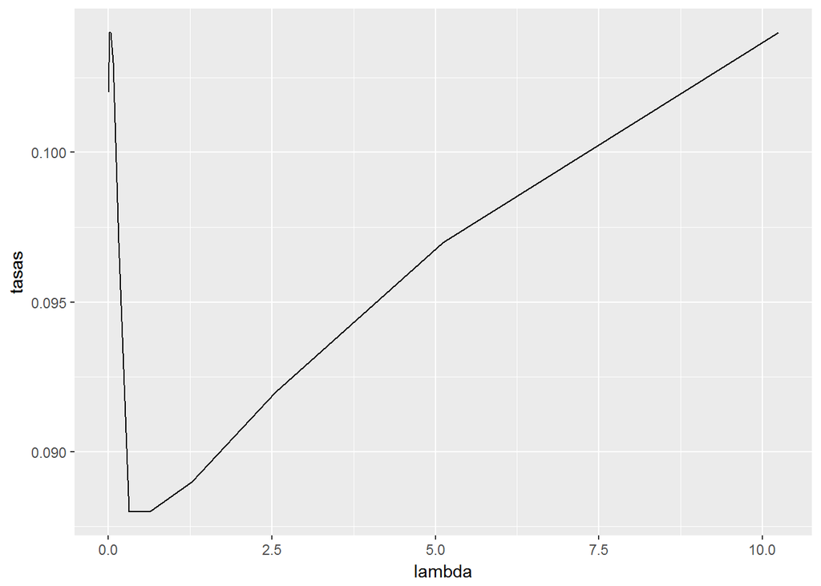

```r
## completad para representar la tasa de misclasificación en  función de lambda
p <- misclassification.dat %>%
  ggplot(aes(x=lambda,y=tasas))
p+geom_line()
```

## Comprobación de la bondad de la clasificación sobre el conjunto de test

Una vez que habéis escogido el mejor lambda en el apartado anterior, y aprovechando código que aparece previamente, construir un data.frame yfit que contenga la posición de la imagen en el conjunto inicial **digitos**, el digito real, y nuestra clasificación usando la regresión logística que hemos entrenado…

```r
### completar aquí

x.test.mat <- cbind(1, as.matrix(digitos.test[, 2:401]))
y.test <- digitos.test$y
yfit <- data.frame(imagen = test.posiciones,
                   yreal = y.test)

yfit$yfit <-  apply(X = g(x.test.mat %*% t(theta.array[,, 7])),
                      MARGIN=1, FUN=which.max)
```

Obtener la tasa global de error: qué porcentaje de veces se ha clasificado mal un dígito..

```r
## completar aquí
(sum(yfit$yreal!=yfit$yfit)/nrow(yfit))*100
```

```
## [1] 5.973864
```

```r
## Obtened la matriz de clasificación (podréis usar "table"")
table(yfit$yreal,yfit$yfit)
```

[output not shown]

En qué dígito cometemos menos errores de clasificación? En qué dígito nos equivocamos más a menudo?

Usando el código del principio de este documento, representad las imágenes que corresponden al error de clasificación más común.

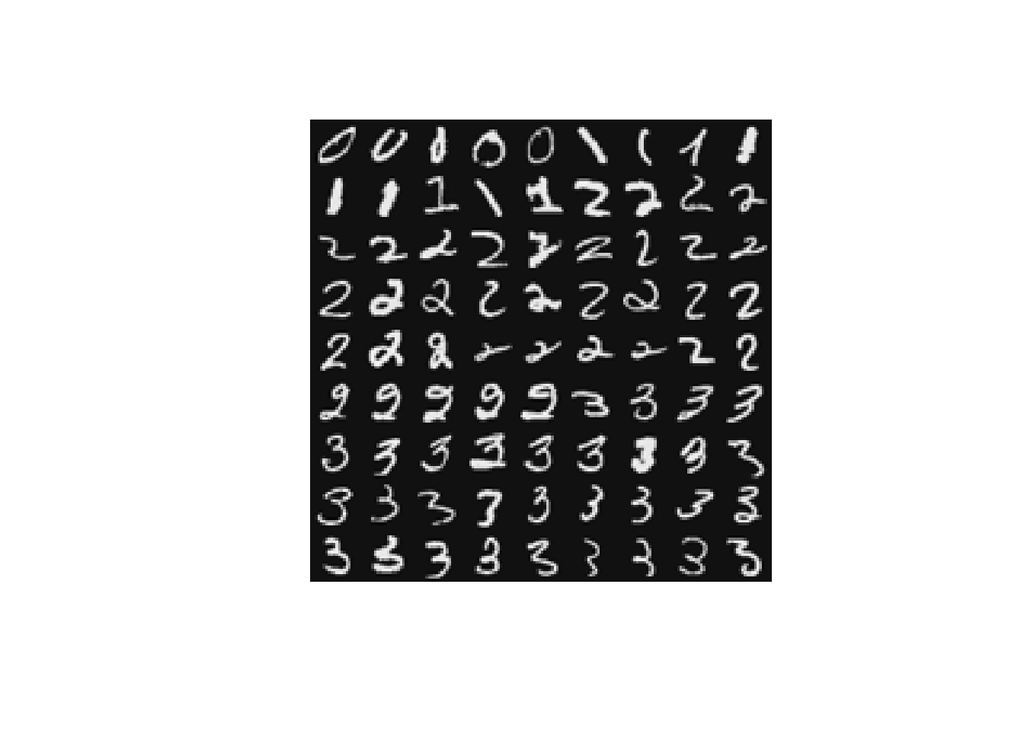

```r
## completar aquí
ex <- yfit %>%
  filter(yfit!=yreal)
iselect <- ex$imagen
ncolumnas <- sqrt(length(iselect))
nfilas <- ncolumnas
m={}
for (i in 1:nfilas){
  mfila={}
  for (j in 1:ncolumnas){
    m.tmp <-
      matrix(as.vector(t(digitos[iselect[1 + (i - 1) * ncolumnas + j - 1],
                                 2:401])), ncol = 20 , nrow = 20)
    mfila <- cbind(mfila, m.tmp)
    }
 m <- rbind(m, mfila)
}
image(z = rotate(m), axes = FALSE,
      col = grey(seq(0, 1, length = 256)), asp = 1)
```